# Dimensionality reduction techniques - week 5

## Task 1

```r
setwd("D:/New folder/OneDrive for Business 1/Git/IODS/IODS-project/data")
human <- read.table(file = "human.txt",
                    header = TRUE,
                    dec = ".")
```

```r
# Libraries
library(GGally)
```

```r
library(corrplot)
library(FactoMineR)
library(tidyr)
library(dplyr)
# Overview of data
summary(human)
```

```
##     sec.edu         lab.force       expec.birth      expec.edu
##  Min.   :0.1717   Min.   :0.1857   Min.   :49.00   Min.   : 5.40
##  1st Qu.:0.7264   1st Qu.:0.5984   1st Qu.:66.30   1st Qu.:11.25
##  Median :0.9375   Median :0.7535   Median :74.20   Median :13.50
##  Mean   :0.8529   Mean   :0.7074   Mean   :71.65   Mean   :13.18
##  3rd Qu.:0.9968   3rd Qu.:0.8535   3rd Qu.:77.25   3rd Qu.:15.20
##  Max.   :1.4967   Max.   :1.0380   Max.   :83.50   Max.   :20.20
##       GNI           mort.ratio       adol.birth       repres.par
##  Min.   :   581   Min.   :   1.0   Min.   :  0.60   Min.   : 0.00
##  1st Qu.:  4198   1st Qu.:  11.5   1st Qu.: 12.65   1st Qu.:12.40
##  Median : 12040   Median :  49.0   Median : 33.60   Median :19.30
##  Mean   : 17628   Mean   : 149.1   Mean   : 47.16   Mean   :20.91
##  3rd Qu.: 24512   3rd Qu.: 190.0   3rd Qu.: 71.95   3rd Qu.:27.95
##  Max.   :123124   Max.   :1100.0   Max.   :204.80   Max.   :57.50
```

```r
str(human)
```

```
## 'data.frame':    155 obs. of  8 variables:
##  $ sec.edu    : num  1.007 0.997 0.983 0.989 0.969 ...
##  $ lab.force  : num  0.891 0.819 0.825 0.884 0.829 ...
##  $ expec.birth: num  81.6 82.4 83 80.2 81.6 80.9 80.9 79.1 82 81.8 ...
##  $ expec.edu  : num  17.5 20.2 15.8 18.7 17.9 16.5 18.6 16.5 15.9 19.2 ...
##  $ GNI        : int  64992 42261 56431 44025 45435 43919 39568 52947 42155 32689 ...
##  $ mort.ratio : int  4 6 6 5 6 7 9 28 11 8 ...
##  $ adol.birth : num  7.8 12.1 1.9 5.1 6.2 3.8 8.2 31 14.5 25.3 ...
##  $ repres.par : num  39.6 30.5 28.5 38 36.9 36.9 19.9 19.4 28.2 31.4 ...
```

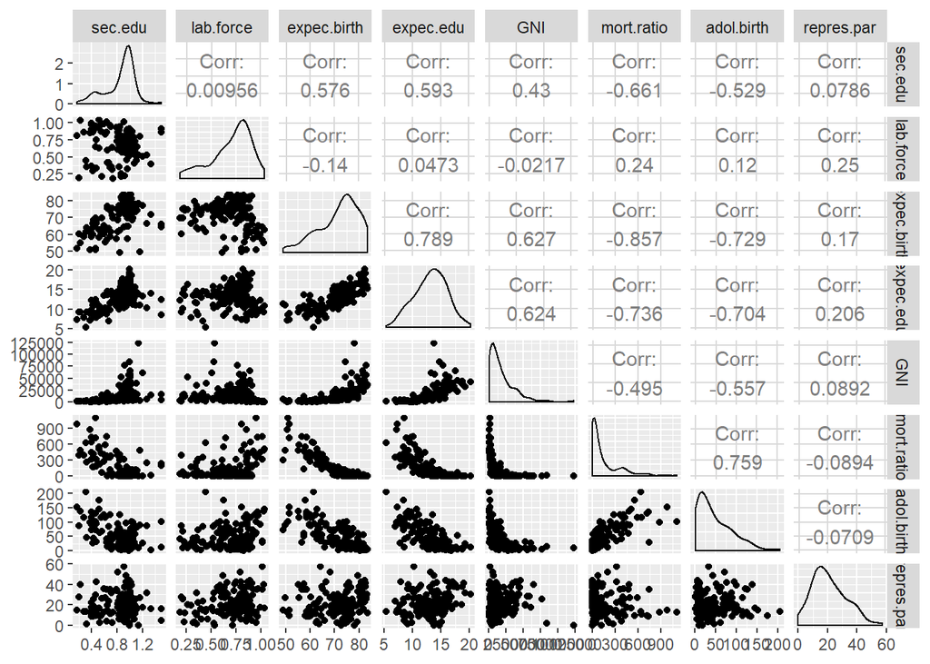

```r
ggpairs(human)
```

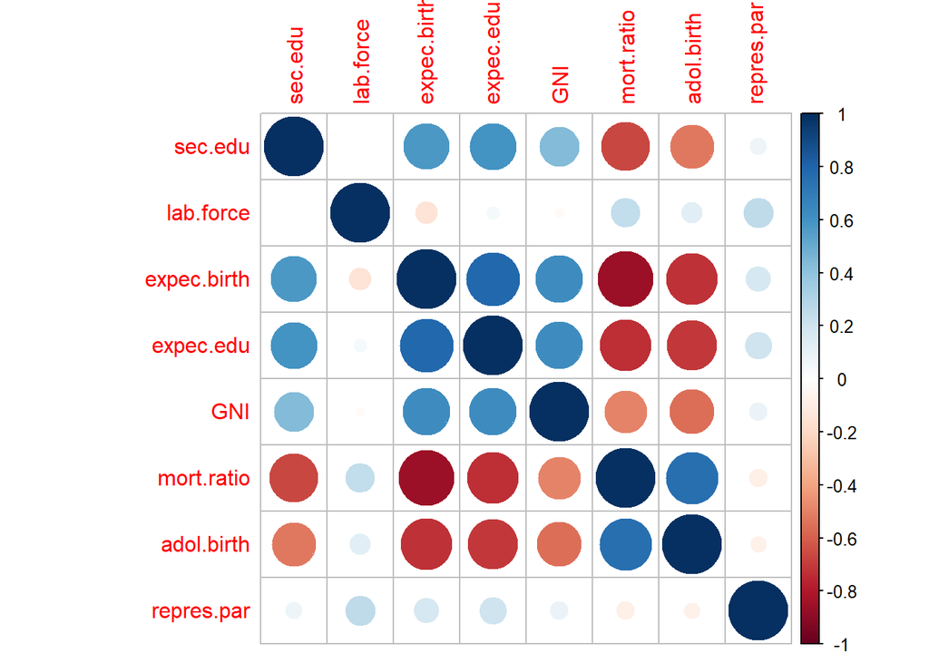

```r
cor(human)%>%corrplot()
```

```r
#Several variables strongly correlate to each other.
```

## Task 2

```r
# PCA on raw data
pca_human_raw <- prcomp(human, scale = FALSE)
pca_human_raw
```

```
## Standard deviations (1, .., p=8):
## [1] 1.854416e+04 1.855219e+02 2.518701e+01 1.145441e+01 3.766241e+00
## [6] 1.565912e+00 1.912052e-01 1.591112e-01
##
## Rotation (n x k) = (8 x 8):
##                       PC1           PC2           PC3           PC4
## sec.edu     -5.607472e-06  0.0006713951 -3.412027e-05 -2.736326e-04
## lab.force    2.331945e-07 -0.0002819357  5.302884e-04 -4.692578e-03
## expec.birth -2.815823e-04  0.0283150248  1.294971e-02 -6.752684e-02
## expec.edu   -9.562910e-05  0.0075529759  1.427664e-02 -3.313505e-02
## GNI         -9.999832e-01 -0.0057723054 -5.156742e-04  4.932889e-05
## mort.ratio   5.655734e-03 -0.9916320120  1.260302e-01 -6.100534e-03
## adol.birth   1.233961e-03 -0.1255502723 -9.918113e-01  5.301595e-03
## repres.par  -5.526460e-05  0.0032317269 -7.398331e-03 -9.971232e-01
##                       PC5           PC6           PC7           PC8
## sec.edu     -0.0022935252  2.180183e-02  6.998623e-01  7.139410e-01
## lab.force    0.0022190154  3.264423e-02  7.132267e-01 -7.001533e-01
## expec.birth  0.9865644425 -1.453515e-01  5.380452e-03  2.281723e-03
## expec.edu    0.1431180282  9.882477e-01 -3.826887e-02  7.776451e-03
## GNI         -0.0001135863 -2.711698e-05 -8.075191e-07 -1.176762e-06
## mort.ratio   0.0266373214  1.695203e-03  1.355518e-04  8.371934e-04
## adol.birth   0.0188618600  1.273198e-02 -8.641234e-05 -1.707885e-04
## repres.par  -0.0716401914 -2.309896e-02 -2.642548e-03  2.680113e-03
```

Among all variables, GNI had a stronger correlation with PC1. Since the variables weren’t standardized, the magnitude and range of some variables, especially of GNI, was much greater, so the PCA gave more emphasis to GNI.

```r
s <- summary(pca_human_raw)
s
```

```
## Importance of components:
##                              PC1      PC2   PC3   PC4   PC5   PC6    PC7
## Standard deviation     1.854e+04 185.5219 25.19 11.45 3.766 1.566 0.1912
## Proportion of Variance 9.999e-01   0.0001  0.00  0.00 0.000 0.000 0.0000
## Cumulative Proportion  9.999e-01   1.0000  1.00  1.00 1.000 1.000 1.0000
##                           PC8
## Standard deviation     0.1591
## Proportion of Variance 0.0000
## Cumulative Proportion  1.0000
```

PC1 explains 100% of the total variance in the data.

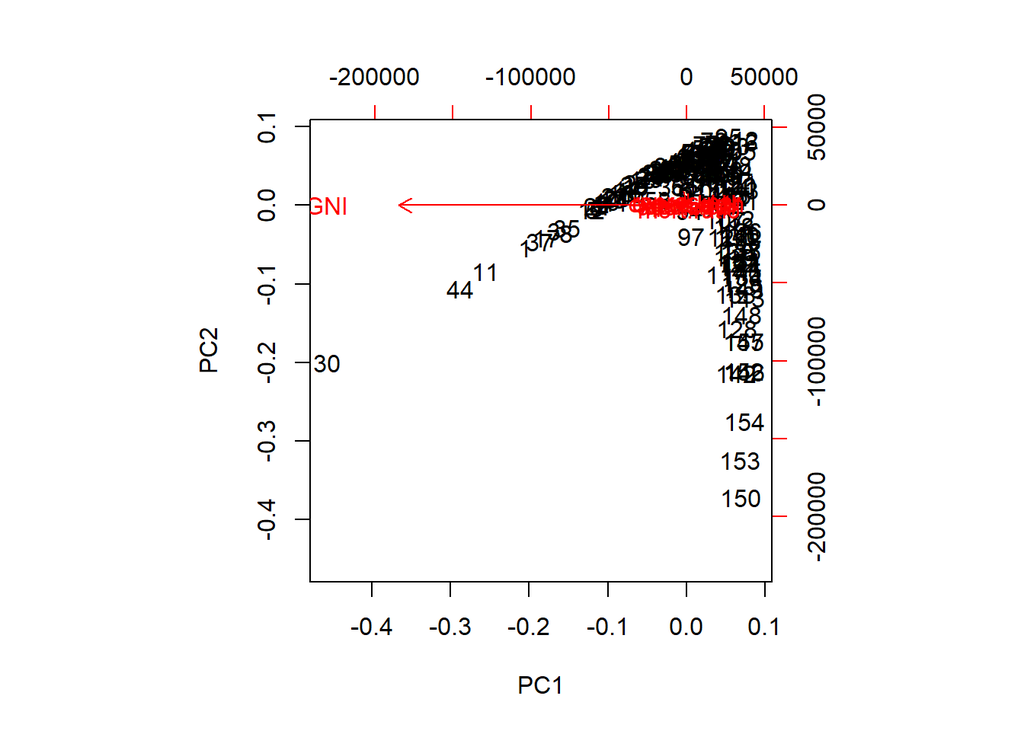

```r
# Draw a biplot of the principal component representation and the original variables
biplot(pca_human_raw)
```

## Task 3

```r
# PCA with standardized data
pca_human_std <- prcomp(human, scale=TRUE)
pca_human_std
```

```
## Standard deviations (1, .., p=8):
## [1] 2.0708380 1.1397204 0.8750485 0.7788630 0.6619563 0.5363061 0.4589994
## [8] 0.3222406
##
## Rotation (n x k) = (8 x 8):
##                     PC1         PC2         PC3         PC4        PC5
## sec.edu     -0.35664370  0.03796058 -0.24223089  0.62678110 -0.5983585
## lab.force    0.05457785  0.72432726 -0.58428770  0.06199424  0.2625067
## expec.birth -0.44372240 -0.02530473  0.10991305 -0.05834819  0.1628935
## expec.edu   -0.42766720  0.13940571 -0.07340270 -0.07020294  0.1659678
## GNI         -0.35048295  0.05060876 -0.20168779 -0.72727675 -0.4950306
## mort.ratio   0.43697098  0.14508727 -0.12522539 -0.25170614 -0.1800657
## adol.birth   0.41126010  0.07708468  0.01968243  0.04986763 -0.4672068
## repres.par  -0.08438558  0.65136866  0.72506309  0.01396293 -0.1523699
##                     PC6         PC7         PC8
## sec.edu      0.17713316  0.05773644  0.16459453
## lab.force   -0.03500707 -0.22729927 -0.07304568
## expec.birth -0.42242796 -0.43406432  0.62737008
## expec.edu   -0.38606919  0.77962966 -0.05415984
## GNI          0.11120305 -0.13711838 -0.16961173
## mort.ratio   0.17370039  0.35380306  0.72193946
## adol.birth  -0.76056557 -0.06897064 -0.14335186
## repres.par   0.13749772  0.00568387 -0.02306476
```

Life expectancy at birth, Expected years of schooling, Proportion of females/males with at least secondary education, and Gross National Income per capita show a strong and negative correlation with PC1, while Maternal mortality ratio and Adolescent birth rate showed a strong positive correlation with PC1. Percetange of female representatives in parliament and Proportion of females/males in the labour force showed a strong positive correlation with PC2.

```r
# Create and print out a summary of pca_human
s <- summary(pca_human_std)
s
```

```
## Importance of components:
##                           PC1    PC2     PC3     PC4     PC5     PC6
## Standard deviation     2.0708 1.1397 0.87505 0.77886 0.66196 0.53631
## Proportion of Variance 0.5361 0.1624 0.09571 0.07583 0.05477 0.03595
## Cumulative Proportion  0.5361 0.6984 0.79413 0.86996 0.92473 0.96069
##                            PC7     PC8
## Standard deviation     0.45900 0.32224
## Proportion of Variance 0.02634 0.01298
## Cumulative Proportion  0.98702 1.00000
```

```r
# Assigning the proportion of variance as percent to each PC
pca_pr <- round(100*s$importance[2, ], digits = 1)
pc_lab<-paste0(names(pca_pr), " (", pca_pr, "%)")
pc_lab
```

```
## [1] "PC1 (53.6%)" "PC2 (16.2%)" "PC3 (9.6%)"  "PC4 (7.6%)"  "PC5 (5.5%)"
## [6] "PC6 (3.6%)"  "PC7 (2.6%)"  "PC8 (1.3%)"
```

The PCA produced two components with eigenvalues (in units of standard deviation) above 1.0, which explained about 70% of the total variance among the eight original variables.

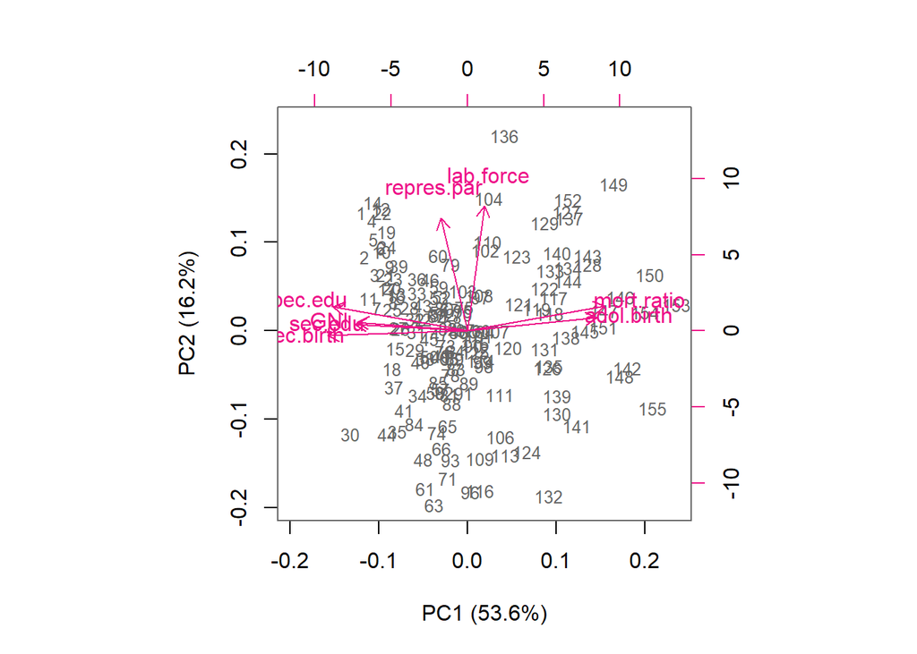

```r
# Draw a biplot of the principal component representation and the original variables
biplot(pca_human_std, cex = c(0.8, 1), col = c("grey40", "deeppink2"), xlab = pc_lab[1], ylab = pc_lab[2])
```

## Task 4

We can see that PC1 and PC1 explained 53.6% and 16.2% of the total variance, respectively. PC1 represents Life expectancy at birth, Expected years of schooling, Proportion of females/males with at least secondary education, and Gross National Income per capita, that strongly correlates with each other, which negatively correlate with Maternal mortality ratio and Adolescent birth rate, that strongly correlate with each other. On the other hand, PC2 represents Percetange of female representatives in parliament and Proportion of females/males in the labour force, which are independent from the other variables in the data set. You can see they are orthogonally positioned on the biplot.

## Task 5

```r
data("tea")
dim(tea)
```

```
## [1] 300  36
```

```r
str(tea)
```

```
## 'data.frame':    300 obs. of  36 variables:
##  $ breakfast       : Factor w/ 2 levels "breakfast","Not.breakfast": 1 1 2 2 1 2 1 2 1 1 ...
##  $ tea.time        : Factor w/ 2 levels "Not.tea time",..: 1 1 2 1 1 1 2 2 2 1 ...
##  $ evening         : Factor w/ 2 levels "evening","Not.evening": 2 2 1 2 1 2 2 1 2 1 ...
##  $ lunch           : Factor w/ 2 levels "lunch","Not.lunch": 2 2 2 2 2 2 2 2 2 2 ...
##  $ dinner          : Factor w/ 2 levels "dinner","Not.dinner": 2 2 1 1 2 1 2 2 2 2 ...
##  $ always          : Factor w/ 2 levels "always","Not.always": 2 2 2 2 1 2 2 2 2 2 ...
##  $ home            : Factor w/ 2 levels "home","Not.home": 1 1 1 1 1 1 1 1 1 1 ...
##  $ work            : Factor w/ 2 levels "Not.work","work": 1 1 2 1 1 1 1 1 1 1 ...
##  $ tearoom         : Factor w/ 2 levels "Not.tearoom",..: 1 1 1 1 1 1 1 1 1 2 ...
##  $ friends         : Factor w/ 2 levels "friends","Not.friends": 2 2 1 2 2 2 1 2 2 2 ...
##  $ resto           : Factor w/ 2 levels "Not.resto","resto": 1 1 2 1 1 1 1 1 1 1 ...
##  $ pub             : Factor w/ 2 levels "Not.pub","pub": 1 1 1 1 1 1 1 1 1 1 ...
##  $ Tea             : Factor w/ 3 levels "black","Earl Grey",..: 1 1 2 2 2 2 2 1 2 1 ...
##  $ How             : Factor w/ 4 levels "alone","lemon",..: 1 3 1 1 1 1 1 3 3 1 ...
```

[output cut: 22 more lines]

```r
keep_columns <- c("Tea", "age", "How", "where", "friends", "breakfast")
tea_time <- select(tea, one_of(keep_columns))
summary(tea_time)
```

```
##         Tea           age           How                       where
##  black    : 74   Min.   :15.00   alone:195   chain store         :192
##  Earl Grey:193   1st Qu.:23.00   lemon: 33   chain store+tea shop: 78
##  green    : 33   Median :32.00   milk : 63   tea shop            : 30
##                  Mean   :37.05   other:  9
##                  3rd Qu.:48.00
##                  Max.   :90.00
##         friends            breakfast
##  friends    :196   breakfast    :144
##  Not.friends:104   Not.breakfast:156
##
##
##
##
```

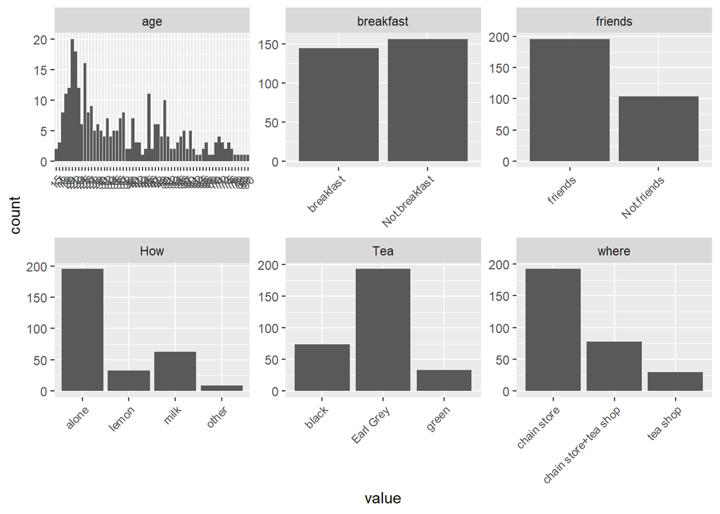

```r
gather(tea_time) %>% ggplot(aes(value)) + facet_wrap("key", scales = "free") +geom_bar()+
  theme(axis.text.x = element_text(angle = 45, hjust = 1, size = 8))
```

```r
mca <- MCA(tea_time, quanti.sup= 2, graph = FALSE)
summary(mca)
```

```
##
## Call:
## MCA(X = tea_time, quanti.sup = 2, graph = FALSE)
##
##
## Eigenvalues
##                        Dim.1   Dim.2   Dim.3   Dim.4   Dim.5   Dim.6
## Variance               0.292   0.266   0.235   0.218   0.180   0.165
## % of var.             16.242  14.803  13.044  12.128   9.975   9.186
## Cumulative % of var.  16.242  31.045  44.088  56.216  66.191  75.377
##                        Dim.7   Dim.8   Dim.9
## Variance               0.156   0.145   0.142
## % of var.              8.693   8.028   7.902
## Cumulative % of var.  84.070  92.098 100.000
##
## Individuals (the 10 first)
##                         Dim.1    ctr   cos2    Dim.2    ctr   cos2
## 1                    | -0.339  0.131  0.081 |  0.824  0.849  0.477 |
## 2                    | -0.084  0.008  0.003 |  1.262  1.994  0.770 |
## 3                    | -0.188  0.040  0.057 | -0.406  0.207  0.266 |
## 4                    | -0.564  0.362  0.356 | -0.007  0.000  0.000 |
## 5                    | -0.362  0.149  0.141 |  0.403  0.203  0.176 |
## 6                    | -0.564  0.362  0.356 | -0.007  0.000  0.000 |
## 7                    |  0.014  0.000  0.000 |  0.003  0.000  0.000 |
## 8                    | -0.286  0.093  0.040 |  0.853  0.909  0.357 |
## 9                    |  0.477  0.260  0.112 |  0.699  0.611  0.241 |
## 10                   |  0.246  0.069  0.032 |  0.681  0.580  0.246 |
##                       Dim.3    ctr   cos2
## 1                     0.207  0.061  0.030 |
## 2                     0.302  0.129  0.044 |
## 3                    -0.495  0.348  0.395 |
## 4                    -0.345  0.169  0.134 |
## 5                    -0.355  0.179  0.136 |
## 6                    -0.345  0.169  0.134 |
## 7                    -0.505  0.362  0.390 |
## 8                     0.311  0.137  0.047 |
## 9                    -0.073  0.008  0.003 |
## 10                    0.395  0.221  0.083 |
##
## Categories (the 10 first)
```

[output cut: 19 more lines]

```
## chain store            0.086   5.057 |  -0.349   6.634   0.216  -8.042 |
## chain store+tea shop   0.008  -1.535 |   0.105   0.243   0.004   1.073 |
## tea shop               0.114  -5.847 |   1.960  32.738   0.427  11.299 |
##
## Categorical variables (eta2)
##                        Dim.1 Dim.2 Dim.3
## Tea                  | 0.273 0.233 0.473 |
## How                  | 0.377 0.439 0.206 |
## where                | 0.503 0.140 0.465 |
## friends              | 0.233 0.241 0.030 |
## breakfast            | 0.074 0.279 0.000 |
##
## Supplementary continuous variable
##                        Dim.1   Dim.2   Dim.3
## age                  | 0.086 | 0.124 | 0.327 |
```

Of all variables,“where” correlated more strongly with dimension 1 (but also with dimension 3), whereas “How” correlated more with dimension 2.“Tea” type correlated with dimension 3. All variables were significant in dim 1. Chain store+tea shop was not significant for dim 2 nor for dim 3. Tea with milk was not significant for dim 3.

```r
dimdesc(mca)
```

```
## $`Dim 1`
## $`Dim 1`$quali
##                   R2      p.value
## where     0.50324995 7.524557e-46
## How       0.37732687 3.019445e-30
## Tea       0.27340440 2.523338e-21
## friends   0.23345584 5.912544e-19
## breakfast 0.07435432 1.631644e-06
##
## $`Dim 1`$category
##                        Estimate      p.value
## chain store+tea shop  0.6096501 1.226985e-46
## friends               0.2744774 5.912544e-19
## other                 0.7852368 1.032975e-12
## lemon                 0.1149361 2.145542e-10
## breakfast             0.1475566 1.631644e-06
## Earl Grey             0.2865841 9.404111e-05
## black                 0.3200220 2.363933e-02
## milk                 -0.2641891 5.285459e-03
## tea shop             -0.3647031 3.913470e-04
## Not.breakfast        -0.1475566 1.631644e-06
## Not.friends          -0.2744774 5.912544e-19
## alone                -0.6359838 1.738080e-21
## chain store          -0.2449470 4.942560e-22
## green                -0.6066061 2.168456e-22
##
##
## $`Dim 2`
## $`Dim 2`$quanti
##     correlation    p.value
## age   0.1240196 0.03176052
##
## $`Dim 2`$quali
##                  R2      p.value
## How       0.4391124 6.243692e-37
## breakfast 0.2792945 5.542412e-23
## friends   0.2410491 1.320700e-19
## Tea       0.2332503 7.431185e-18
## where     0.1395386 2.030530e-10
##
```

[output cut: 26 more lines]

```
## How     0.20575294 9.869805e-15
## friends 0.02992583 2.642919e-03
##
## $`Dim 3`$category
##                Estimate      p.value
## tea shop     0.67270547 6.462175e-38
## black        0.18432316 2.573512e-19
## green        0.29135270 1.409740e-11
## other        0.55976812 5.224949e-08
## lemon        0.12601180 1.086269e-07
## Not.friends  0.08806502 2.642919e-03
## friends     -0.08806502 2.642919e-03
## alone       -0.39818668 5.000153e-08
## chain store -0.44621500 1.655193e-17
## Earl Grey   -0.47567587 6.638625e-43
```

Age is significantly correlated with dim 2 (p<0.05) and dim 3 (p<0.001).

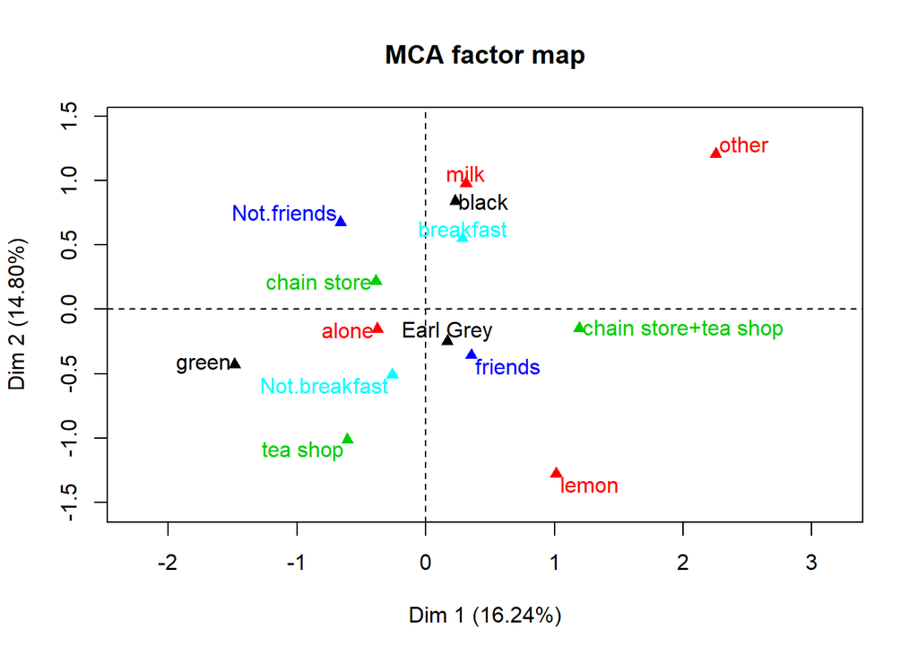

```r
plot(mca, invisible=c("ind"),habillage = "quali")
```